# GLM para dados contínuos

Maiara Menezes

2025-10-18

## 1 Introdução

Para exercitar a análise da dados contínuos vamos utilizar o banco de dados `mammals_sleep`, extraído do trabalho publicado por Allison & Cicchetti (1976).

- Allison, T. and Cicchetti, D.V. (1976). Sleep in mammals: ecological and constitutional correlates. Science, 194(4266), pp.732-734. doi: 10.1126/science.982039

Esse banco de dados, reúne informações sobre hábitos de sono e outras características de espécies adaptadas a uma ampla variedade de nichos ecológicos.

Variáveis incluídas que serão utilizadas nesse exercício:

- Mammals: grupos de mamíferos
- Body : massa corporal (g)
- Sleep : número total de horas dormidas por dia
- Predation : índice de predação: 1 = mínimo (menos provável de ser predado) a 5 = máximo (mais provável de ser predado)
- Exposure : índice de exposição durante o sono: 1 = menos exposto (o animal dorme em uma toca bem protegida) 5 = mais exposto

Vamos começar importando os dados:

```r
#~~~~~~~~~~~~~~~~~~~~~~~~~~~~~~~~
# 1. Importando o banco de dados
#~~~~~~~~~~~~~~~~~~~~~~~~~~~~~~~~
dados <- readRDS("../Dados/mammal_sleep.rds")
str(dados)
```

```
## 'data.frame':    62 obs. of  11 variables:
##  $ mammals  : chr  "African.elephant" "African.giant.pouched.rat" "Arctic.Fox" "Arctic.ground.squirrel" ...
##  $ body     : num  6654 1 3.38 0.92 2547 ...
##  $ brain    : num  5712 6.6 44.5 5.7 4603 ...
##  $ nondream : num  NA 6.3 NA NA 2.1 9.1 15.8 5.2 10.9 8.3 ...
##  $ dream    : num  NA 2 NA NA 1.8 0.7 3.9 1 3.6 1.4 ...
##  $ sleep    : num  3.3 8.3 12.5 16.5 3.9 9.8 19.7 6.2 14.5 9.7 ...
##  $ lifespan : num  38.6 4.5 14 NA 69 27 19 30.4 28 50 ...
##  $ gestation: num  645 42 60 25 624 180 35 392 63 230 ...
##  $ predation: int  3 3 1 5 3 4 1 4 1 1 ...
##  $ exposure : int  5 1 1 2 5 4 1 5 2 1 ...
##  $ danger   : int  3 3 1 3 4 4 1 4 1 1 ...
```

Antes de seguir com a análise dos dados podemos ver que no nosso banco de dados há alguns NAs que podem prejudicar nossa análise. Para seguir então podemos removê-los. Além disso, temos duas variáveis categóricas que precisam ser reconhecidas como fatores.

```r
dados<- na.omit(dados) #remove os NAs

cols <- c("exposure","predation")
dados[, cols] <- lapply(dados[, cols], factor)
```

### 1.1 Objetivos

Queremos investigar se a qualidade de sono (duração do sono por dia) tem alguma relação com o tamanho do corpo das espécies e com a sua exposição a predação durante esse período. Nossa pergunta é: Animais grandes dormem mais durante o dia do que animais pequenos? E, animais pequenos devem dormir menos por estarem mais propensos a predação enquanto dormem?

Agora podemos plotar nossa variável de interesse para ver como é sua distribuição, o que irá nos ajudar a definir o tipo de modelo que iremos contruir.

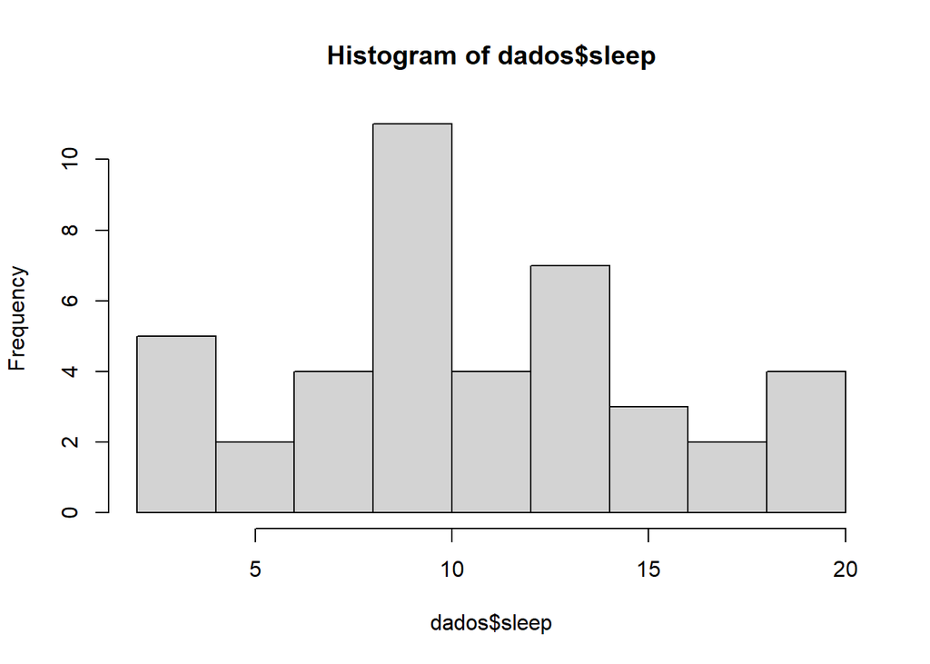

```r
#~~~~~~~~~~~~~~~~~~~~~~~~~~~~~~~~
# 2. Explorando o banco de dados
#~~~~~~~~~~~~~~~~~~~~~~~~~~~~~~~~

hist(dados$sleep)
```

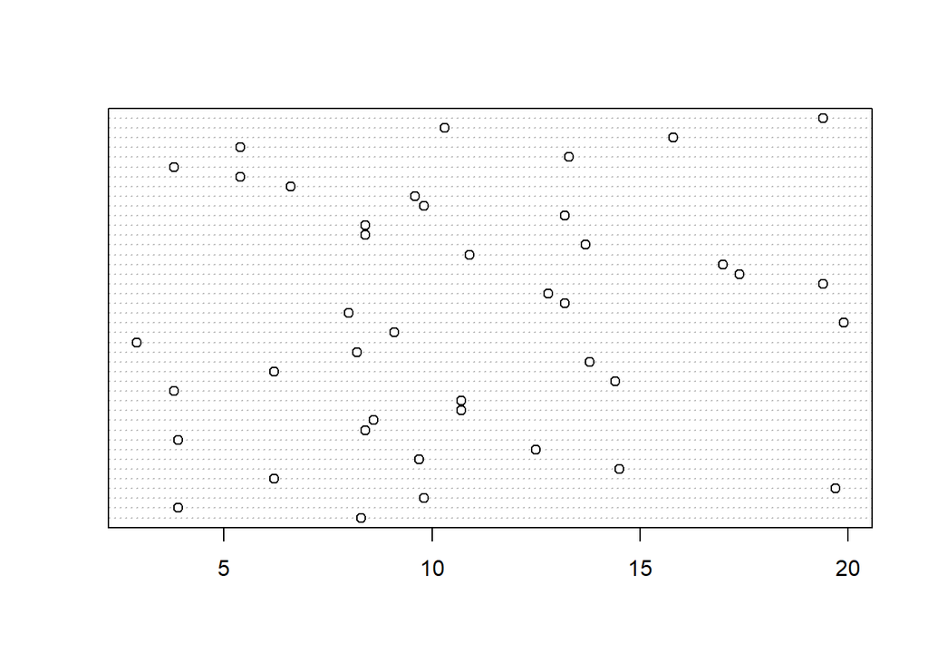

```r
dotchart(dados$sleep)
```

Observamos que nossos dados apresentam uma distribuição próxima da normal e aparentemente não apresentam nenhum padrão de variabilidade específico. Podemos verificar se a distribuição equivale a uma gaussiana fazendo o teste de shapiro-wilk.

```r
shapiro.test(dados$sleep) #Teste de normalidade
```

```
##
##  Shapiro-Wilk normality test
##
## data:  dados$sleep
## W = 0.95769, p-value = 0.122
```

Podemos ainda investigar se existe alguma relação geral entre o tempo de sono e as covariáveis: massa corporal, índice de predação e índice de exposição durante o sono.

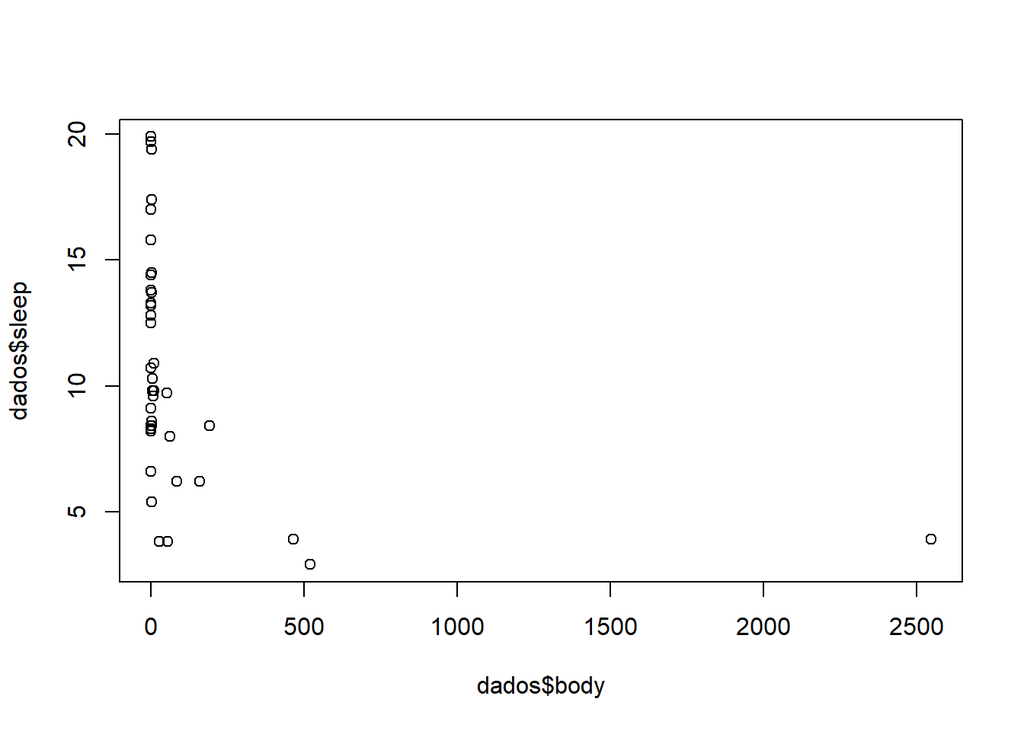

```r
plot(dados$sleep~dados$body)
```

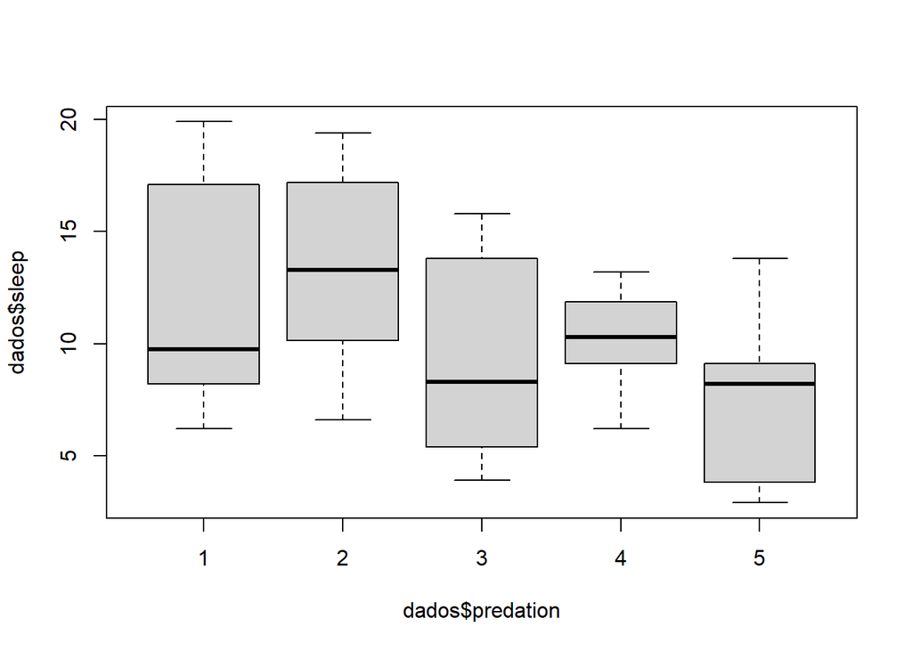

```r
plot(dados$sleep~dados$predation)
```

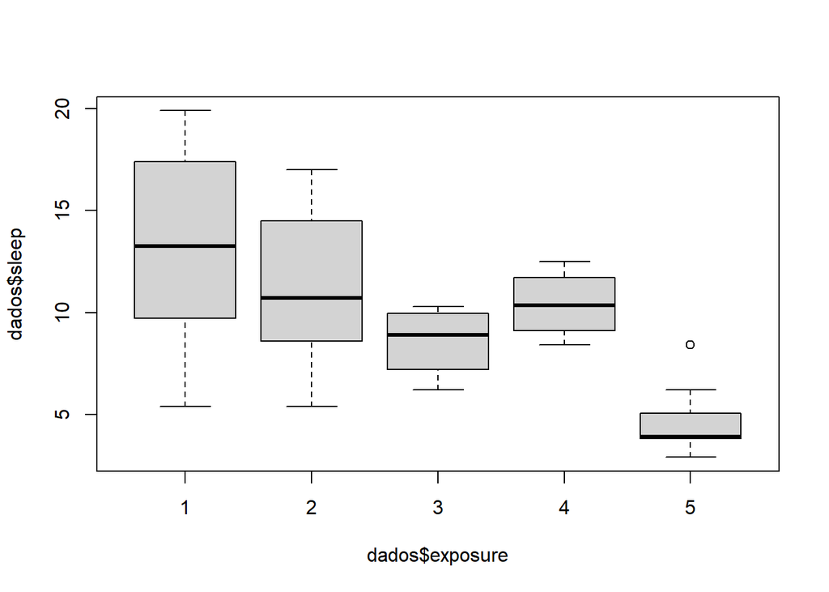

```r
plot(dados$sleep~dados$exposure)
```

Observando o primeiro gráfico, vemos que há 1 outlier representado pelo elefante asiático, que é um animal de massa corporal muito elevada, logo não configura um erro de importação de dados, e será mantido nas análises. Adicionalmente, vemos que há uma uma relação negativa entre tempo de sono e a massa corporal que precisa ser investigada.

Além disso, o grau de exposição à predação parece influenciar o tempo de sono negativamente. Em geral, espera-se que os indivíduos mais predados e que dormem mais expostos, tenham prejudizos quanto ao tempo que podem passar dormindo.

### 1.2 Hipóteses

- $H_1$ O tamanho do corpo influencia o tempo do sono
- $H_2$ A propenção à predação influencia o tempo do sono
- $H_3$ A exposição à predação durante o sono influencia o tempo do sono

## 2 Metodologia

Para avaliar se o tempo diário gasto dormindo está relacionado ao tamanho corporal das espécies e à índices de exposição à predação, utilizaremos dois modelos de distribuição: Gama e log-normal, visto que a variável resposta (total de horas de sono por dia) é contínua.

A distribuição Gama é definida pela fórmula:

$$\large f(y; \alpha, \beta) =
\frac{\beta^{\alpha} y^{\alpha - 1} e^{-\beta y}}{\Gamma(\alpha)}, \quad
y > 0$$
Esta função nos dá a probabilidade da i*esma* espécie ter um tempo de sono $y_i$, estimado à partir de uma média $\alpha$ e de uma variância $\beta$. Sendo $y$ um valor estritamente positivo.

Já a distribuição Log-normal é definida por:

$$f(y; \mu, \sigma) = \frac{1}{y \sigma
\sqrt{2\pi}} \exp\left(-\frac{(\ln y - \mu)^2}{2\sigma^2}\right), \qquad
y > 0$$
E considera parâmetros distintos da gama. Considerando essas distintas funções de distribuição e seus parâmetros, podemos resumir o nosso modelo conforme:

$$log(\mu) = \eta = \beta_0 + \beta_1 Peso
+ \beta_2 Predação + \beta_3 Exposição$$
Uma vez estruturado o nosso modelo, podemos seguir com a seleção do melhor tipo de distribuição que se ajustará aos nossos dados.

## 3 Análises e Resultados

Iniciaremos as análises comparando os modelos com distribuições gama e log-normal.

```r
#~~~~~~~~~~~~~~~~~~~~~~~~~~~~~~~~
# 3. Testando modelos
#~~~~~~~~~~~~~~~~~~~~~~~~~~~~~~~~

library(glmmTMB)
## Modelo Gama ##
modelo_G <- glmmTMB(sleep ~ body + predation + exposure,
                    family = Gamma(link = "log"),
                    data = dados)



## Modelo log-Normal ##
modelo_LN <- glmmTMB(sleep ~ body + predation + exposure,
                     family = lognormal(link = "log"),
                     data = dados)
```

Agora que temos alguns modelos, podemos compará-los via valores de AIC

```r
#~~~~~~~~~~~~~~~~~~~~~~~~~~~~~~~~
# 4. Comparando os modelos
#~~~~~~~~~~~~~~~~~~~~~~~~~~~~~~~~

library(performance)
library(DHARMa)

## Calcular os valores de AIC ##
AIC(modelo_G,modelo_LN)
```

```
##           df      AIC
## modelo_G  11 232.3140
## modelo_LN 11 231.3683
```

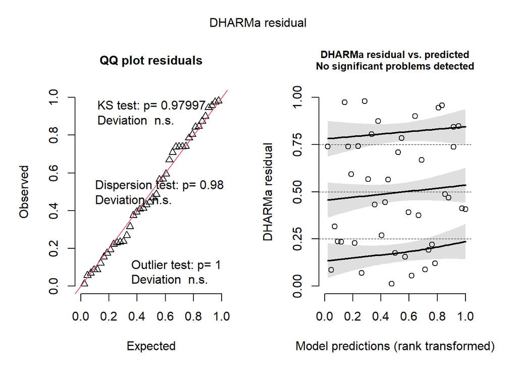

```r
#~~~~~~~~~~~~~~~~~~~~~~~~
# 5) Validação do modelo
#~~~~~~~~~~~~~~~~~~~~~~~~
library(DHARMa)

## Simulando os resíduos a partir do modelo escolhido ##
resid_sim <- simulateResiduals(modelo_G, n=1000)
plot(resid_sim)
```

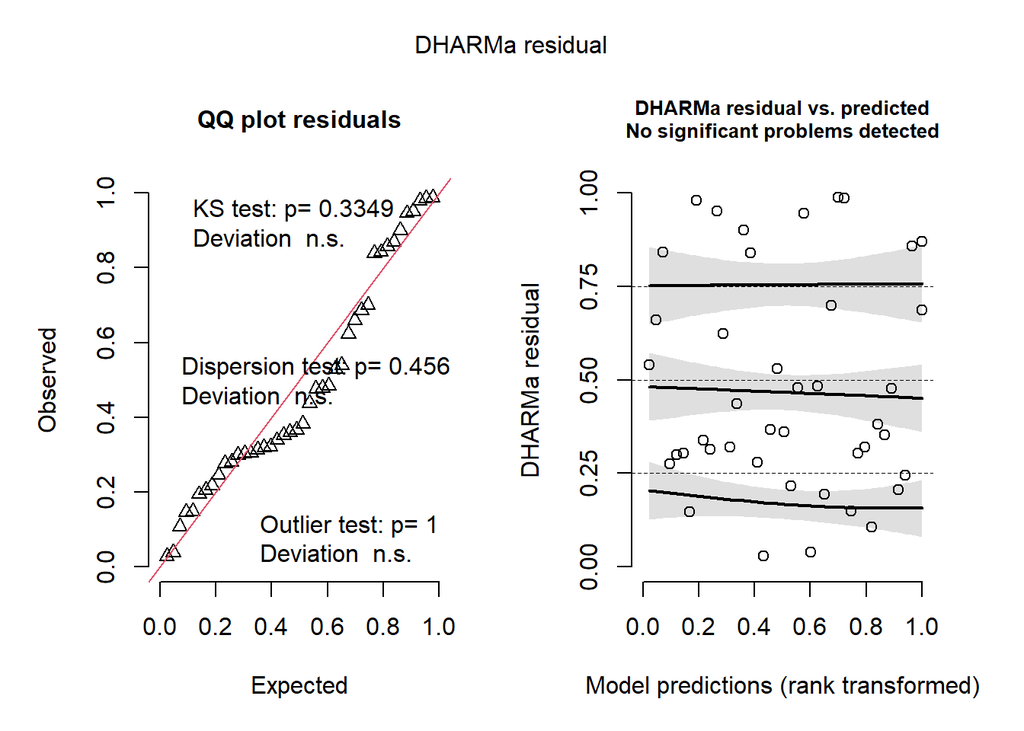

```r
resid_sim2 <- simulateResiduals(modelo_LN, n=1000)
plot(resid_sim2)
```

```r
#~~~~~~~~~~~~~~~~~~~~~~~~~~~~
# 6) Analisando os resultados
#~~~~~~~~~~~~~~~~~~~~~~~~~~~

summary(modelo_G)
```

```
##  Family: Gamma  ( log )
## Formula:          sleep ~ body + predation + exposure
## Data: dados
##
##       AIC       BIC    logLik -2*log(L)  df.resid
##     232.3     251.4    -105.2     210.3        31
##
##
## Dispersion estimate for Gamma family (sigma^2): 0.0933
##
## Conditional model:
##               Estimate Std. Error z value Pr(>|z|)
## (Intercept)  2.5596137  0.1122451  22.804  < 2e-16 ***
## body        -0.0001149  0.0001214  -0.947   0.3439
## predation2   0.1468525  0.1448982   1.013   0.3108
## predation3  -0.1143816  0.1742329  -0.656   0.5115
## predation4   0.0519572  0.1941825   0.268   0.7890
## predation5  -0.0346441  0.2010018  -0.172   0.8632
## exposure2   -0.2137318  0.1285510  -1.663   0.0964 .
## exposure3   -0.4545810  0.1820433  -2.497   0.0125 *
## exposure4   -0.2379853  0.2175407  -1.094   0.2740
## exposure5   -0.9246252  0.2358516  -3.920 8.84e-05 ***
## ---
## Signif. codes:  0 '***' 0.001 '**' 0.01 '*' 0.05 '.' 0.1 ' ' 1
```

Para interpretar nossos resultados, precisamos lembrar que nosso modelo está em escala logaritmica, logo precisamos aplicar a função inversa do log (exponencial) aos nossos coeficientes angulares para retornar a escala natural dos nossos dados.

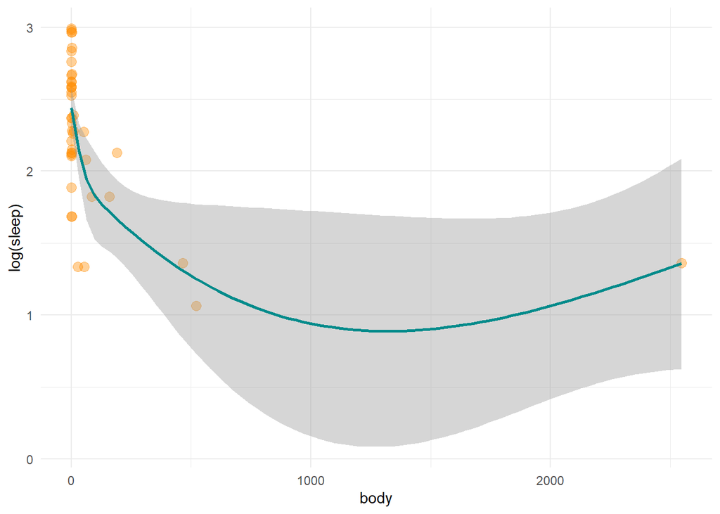

```r
#~~~~~~~~~~~~~~~~~~~~~~~~~~~~
# 7) Representação gráfica dos resultados
#~~~~~~~~~~~~~~~~~~~~~~~~~~~

library(ggplot2)
ggplot(dados, aes(x = body, y = log(sleep))) +
  geom_point(size = 3, col = 'darkorange', alpha = 0.4) +
  geom_smooth(method = "gam", col = 'cyan4') +
  theme_minimal()
```

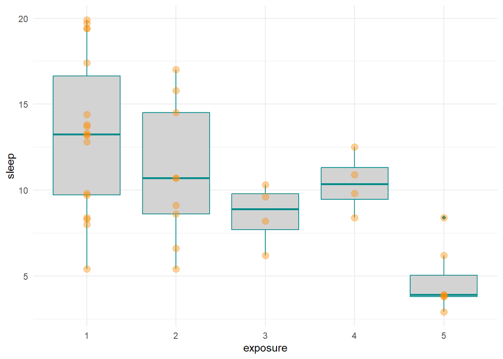

```r
ggplot(dados, aes(x = exposure, y = sleep)) +
  geom_boxplot(fill = 'lightgray', colour = 'cyan4') +
  geom_point(size = 3, col = 'darkorange', alpha = 0.4) +
  theme_minimal()
```